# A Dynamic Search Model for Marriage and Infidelity

Author

Wuyang Ren

Published

April 22, 2026

# Introduction

In Burdett, Imai, and Wright (2002)’s study of endogenous instability in bilateral relationships in a continuous-time setting, an agent who searches while already matched does not observe the quality of a prospective new match until they leave their current partner. This makes the cheating decision fundamentally static: agents choose whether to search outside the relationship at the moment the match is formed, and the equilibrium outcome is characterized by regions of the match values.

This project extends Burdett, Imai, and Wright (2002) into a finite-horizon, discrete-time framework. The finite horizon and discrete time structure allow the problem to be solved with backward induction, making the cheating decision dynamic. Within each period, the two partners play a simultaneous $2 \times 2$ stage game: Faithful or Cheat, and the resulting Nash equilibrium determines transition probabilities into divorce, continued marriage, or a new match.

Another extension is the introduction of match-specific flow utility that grows with marriage duration and is non-transferable across relationships. While married, the flow utility of a match of quality $x$ at tenure $\tau$ is $x + \gamma(\tau)$, where $\gamma(\tau)$ captures relationship-specific investments: shared routines, social networks, joint property, and attachment. These factors are largely non-transferable to a new partner. The baseline specification follows a linear growth pattern. Drawing on Jovanovic (1979), I also consider a concave specification $\gamma(\tau) = \gamma_{\max}(\frac{\rho\tau}{1 + \rho\tau})$, where the marginal return to marriage duration diminishes over time and saturates at $\gamma_{\max}$. The interpretation here is different from Jovanovic (1979) ’s job-matching model, where tenure generates match-specific value through Bayesian updating. Here, the rationale for the concave setup is simply that the marriage-specific capital might grow faster in earlier years of the marriage in reality. Having the growth rate approaching $\gamma_{\max}$ not computational (since the growth stops in $T$ anyways). It is mainly to give more comparative statics to explore. In any case, the frameworks should predict declining separation rates in tenure.

The model also introduces asymmetric divorce costs: the partner who is caught cheating bears a higher cost $\delta_C$ than the faithful partner $\delta_F$. This asymmetry reflects legal and social penalties for infidelity disciplines cheating incentives.

The equilibrium is characterized by the value of being single $V_S$, the strategy profile in each marriage state $s^*(\tau, x)$, and the value of being married at quality $x$ and tenure $\tau$, $V_M(\tau, x)$. From the equilibrium, I obtain the steady-state distribution of marriages and the singles pool, as well as infidelity and divorce rates. Finally, I conduct comparative statics on key parameters. # Implementation

```julia
import Pkg
Pkg.activate(".")
using MarriageModel
using Random
using Distributions
using Printf
```

```
  Activating project at `~/grad_courses/622/project/marriage/infidelity_search`
Precompiling packages...
   4250.5 ms  ✓ MarriageModel (serial)
  1 dependency successfully precompiled in 4 seconds
```

```julia
p = ModelParams()
println(p)
@doc ModelParams
```

```
ModelParams
  β: Float64 0.95
  α: Float64 0.3
  α_prime: Float64 0.15
  b: Float64 0.5
  x_lo: Float64 0.2
  x_hi: Float64 2.0
  Nx: Int64 80
  gamma_spec: LinearGamma
  T: Int64 35
  c: Float64 0.1
  κ: Float64 0.15
  δ_A: Float64 1.0
  δ_C: Float64 1.5
  δ_F: Float64 0.5
  λ: Float64 0.02
  tol: Float64 1.0e-6
  max_iter: Int64 500
```

```
ModelParams
```

All parameters of the marriage/infidelity model.

- α: meeting probability for singles

- α′: meeting probability for cheating agents

- λ: exogenous marriage termination rate

- c: cost of cheating on the cheater

- κ: cost on the faithful partner when the other cheats

- δ_A: amicable divorce cost (both pay)

- δ_C: cheater's divorce cost

- δ_F: faithful partner's divorce cost

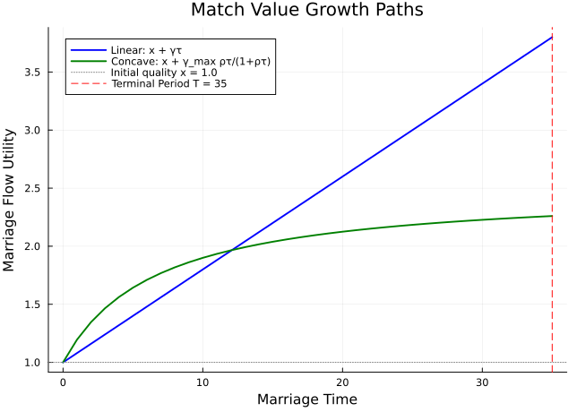

```julia
using Plots
p = ModelParams()
τ_range = 0:1:p.T

g_lin = LinearGamma()
g_con = ConcaveGamma()

x0 = 1.0

u_lin = [x0 + gamma_val(g_lin, τ) for τ in τ_range]
u_con = [x0 + gamma_val(g_con, τ) for τ in τ_range]

plot(τ_range, u_lin,
     label = "Linear: x + γτ",
     lw = 2, color = :blue)
plot!(τ_range, u_con,
      label = "Concave: x + γ_max ρτ/(1+ρτ)",
      lw = 2, color = :green)
hline!([x0], label = "Initial quality x = $x0", ls = :dot, color = :gray)
vline!([p.T], label = "Terminal Period T = $(p.T)", ls = :dash, color = :red)
xlabel!("Marriage Time")
ylabel!("Marriage Flow Utility")
title!("Match Value Growth Paths")
```

## The Cheating Game

### Payoffs

#### Variable Definitions

| Variable | Definition |
| --- | --- |
| $u(\tau, x)$ | Flow utility of a marriage with initial quality $x$ at time $\tau$: $u(\tau,x) = x + \gamma(\tau)$ |
| $W(\tau, x)$ | Discounted continuation value of staying married: $W = \beta\bigl[(1-\lambda)\,V_M(\tau+1,x) + \lambda\,V_S\bigr]$ |
| $V_M(\tau, x)$ | Value of being in a marriage of quality draw$x$ at time $\tau$ |
| $V_S$ | Value of single |
| $x_C$ | Cheater’s reservation quality: $\beta V_M(0, x_C) - \delta_C = W(\tau, x_C)$ |
| $p_c$ | Probability cheater finds an acceptable outside match: $p_c = \alpha'[1 - F(x_C)]$ |
| $\mathbb{1}_{fd}$ | Indicator for faithful partner initiating divorce: $\mathbb{1}(\beta V_S - \delta_F \geq W)$ |

In each period, the couple plays the $2 \times 2$ cheating game with actions $\{Cheat (C), Faithful (F)\}$ $$

$$\begin{array}{c\|cc}
& F & C \\\\ \
F & V^{FF} & V^{FC} \\\\
C & V^{CF} & V^{CC}
\end{array}$$

`payoffs.jl` defines the payoffs for each action profile as follows: 1. Both faithful (F, F)
$$V^{FF}(\tau,x) = u(\tau,x) + W(\tau,x)$$

2. One cheats (F, C)/(C, F)

   Cheater’s payoff:

   $$\begin{align}
   V_1^{CF}(\tau, x) &= u(\tau, x) - c
   + \underbrace{\alpha' \left[ \beta \int_{x_c}^{\bar{x}} V_M(0, x')\, \mathrm{d}F(x')
   - \delta_C \bigl(1 - F(x_c)\bigr) \right]}_{\text{expected gain from leaving}} \\
   &+ (1 - \alpha' \left(1 - F\!\left(x_c\right)\right) \left[
   \mathbb{1}_{fd} \bigl(-\delta_C + \beta V_S\bigr)
   + (1 - \mathbb{1}_{fd})\, W(\tau, x)
   \right]
   \end{align}$$

   Faithful partner’s payoff:

   $$\begin{align}
   V_2^{CF}(\tau, x) &= u(\tau, x) - \kappa
   + \max\Bigl\{
   \underbrace{-\delta_F + \beta V_S}_{\text{leave}},\;
   \underbrace{p_c(-\delta_F + \beta V_S) + (1 - p_c)\,W(\tau, x)}_{\text{stay}}
   \Bigr\}
   \end{align}$$
3. Both cheats (C, C)

   $$\begin{align}V^{CC}(\tau, x) &= u(\tau, x) - c + \alpha \left[\beta \int_{x_c}^{\bar{x}} V_M(0, x')\,\mathrm{d}F(x') - \delta_C\bigl(1 - F(x_c)\bigr) \right] \\
   &\quad + (1 - p_c)\Bigl[ p_c\bigl(-\delta_C + \beta V_S\bigr) + (1 - p_c)\,W(\tau, x) \Bigr]\end{align}$$

The cheater’s reservation $x'$ draw for leaving the current relationship is $\beta V_M(0, x_C) - \delta_C = W(\tau, x_C)$.

Given that $V_M(0, x_C)$ is monotinic in $x$, `find_x_cut` in `functions.jl` solves for $x_C$ using linear interpolation over the grid of $x$ values and their corresponding $V_M(0, x)$. The function checks the boundary conditions to determine if the cheater always stays or always leaves. Otherwise it finds the cutoff $x_C$ where the cheater is indifferent between staying and leaving.

The integral $\int_{x_c}^{\bar{x}} V_M(0, x')\,\mathrm{d}F(x')$ is evaluated numerically in `integral_VM0_above` (`functions.jl`) in two steps. First, since $V_M(0, \cdot)$ is only known at the discrete grid points in `xg`, it is extended to a continuous function via `linear_interpolation` from `Interpolations.jl`. Second, because $F$ is unifim, the integrand reduces to $V_M(0, x') \cdot f$ with constant density, and the integral is then computed with adaptive Gauss–Kronrod quadrature using `quadgk` from `QuadGK.jl`.

The same interpolate-then-`quadgk` process is used in `compute_VS` (`outer_loop.jl`) to evaluate the expected continuation value over outside draws above the reservation quality $x^*$.

### Solving for the Equilibrium

The game can be thought of as a symmetric coordination game. The equilibrium analysis reduces to checking two deviation incentives:

1. $\Delta_F(\tau, x) = V_1^{CF} - V^{FF}$: The gain for a faithful partner from deviating to cheating when the partner remains faithful.
2. $\Delta_C(\tau, x) = V^{CC} - V_2^{CF}$: The gain for a faith partner from deviating to cheating when the partner also cheats.

Given this, the pure-strategy equilibria of the game can be characterized as three regions.

1. $\Delta_F(\tau, x) < 0$ and $\Delta_C(\tau, x) < 0$: both partners choose Faithful (F, F).
2. $\Delta_F(\tau, x) < 0$ and $\Delta_C(\tau, x) \geq 0$: multiple equilibria (F, F) and (C, C). Cheating does not make the player better off when the partner is faithful, but it does when the partner also cheats.
3. $\Delta_F(\tau, x) \geq 0$: both partners choose Cheat (C, C).

When multiplicity arises, we select the outcome that gives the players higher payoffs.

The following code demonstrates the Nash equilibrium computation using nash_equilibrium() with a single state example.

```julia
xg = x_grid(p)
VS = p.b / (1.0 - p.β) # a permanent bachelor
VM0_vals = [match_value(0, x, p) / (1.0 - p.β) for x in xg]

τ = 5
x = 1.0
W = W_cont(match_value(τ + 1, x, p) / (1.0 - p.β), VS, p)

eq_type, s_star, V_eq = nash_equilibrium(τ, x, W, VM0_vals, xg, VS, p)

println("Equilibrium type:", eq_type)
println("Cheating prob s* = ", s_star)
println("Equilirbim payoff = ", V_eq)
```

```
Equilibrium type:CC
Cheating prob s* = 1.0
Equilirbim payoff = 28.486627410508326
```

## Backward Induction

For durations $\tau \geq T$, match quality has stopped evolving, so the marriage problem becomes stationary: the continuation value value of marriage is the same in every period.

The solution algorithm starts with guessing that $T$ is large enough to make cheating unattractive, and so agents remain faithful for every period $\tau \geq T$. From this, the value of marriage in period $T$ is:
$$V_M^\infty(x) = u(T, x) + \beta \big[(1 -\lambda) V_M^\infty(x) +\lambda V_S \big]$$

Solving for $V_M^\infty$:
$$\begin{align}
V_M^\infty(x) = V(T, x)= \frac{u(T, x) + \beta\lambda V_S}{1 - \beta (1 -\lambda)}
\end{align}$$

Given the initial guess of $V(T, x)$, `solve_terminal()` in `backward_induction.jl` computes the continuation value $W(T, x)$ and use `nash_equilibrium()` to solve for the equilibrium payoffs in the terminal period, which gives an updated $V(T, x)$. The process iterates until convergence.

`backward_induction()` then uses the `VM_T` from the terminal period to solve the cheating game in every state $(\tau, x)$ where $\tau < T$.

```julia
VM_T, _, _ = solve_terminal(VM0_vals, xg, VS, p)

V_FF_guess = [(match_value(p.T, x, p) + p.β * p.λ * VS) / (1.0 - p.β * (1.0 - p.λ)) for x in xg]

println("Converged equilibrium payoffs", first(VM_T, 5))
println("Initial guesses: ", first(V_FF_guess, 5))

VM, eq_type_grid, s_star_grid = backward_induction(VM0_vals, xg, VS, p) #returns matrices of size τ * x
```

```
Converged equilibrium payoffs[46.23188405797099, 46.56209869748666, 46.89231333700235, 47.22252797651804, 47.552742616033726]
Initial guesses: [46.23188405797098, 46.56209869748666, 46.89231333700235, 47.22252797651803, 47.55274261603372]
```

[output not shown]

## Fixed-Point Solution for $V_S$

We start with an intial guess for the value of being single $V^0_S = b/(1-\beta)$, which gives the lower bound, as it reflects the case of one being single forever. Similarlu, we initialize the value of marriage at the start of the relationship as $V^0_M(0, x) = u(0,x) / (1 - \beta)$ for each $x$ on the grid, with no flow utility growth, search, or dissolution.

At each iteration $n$ , taking V^n_S and V^n_M(0, x) as given, we solve for the equilibrium payoffs in the cheating game using the backward induction algorithm descried above. The solution gives the value of marriage and equilibrium action profiles for each state, yielding an updated marriage values $V^{n+1}_M(0, x)$ at the start of the relationship.

Using $V^{n+1}_M(0, x)$, we can then find the reservation quality $x^*$ of a single person satisfying $V^{n+1}_M(0, x) = V^n_S$. Following this, we update $V^n_S \rightarrow V^{n+1}_S$ with the recursive bellman equation:

$$V^{n+1}_S = b + \beta \left[ V^{n}_S + \alpha \int_{x^*}^{x^{max}} \big( V_M^{n+1}(0, x) - V_S^{n} \big)\, dF(x) \right]$$

```julia
sol_lin = solve_model(p)

println("V_S = ", sol_lin.VS)
println("x* = ", sol_lin.x_star)
println("V_M(0, x_lo)= ", sol_lin.VM[1, 1])
println("V_M(0, x_hi)= ", sol_lin.VM[1, end])

p_conc = ModelParams(p; gamma_spec=ConcaveGamma())
sol_conc = solve_model(p_conc)

println("V_S = ", sol_conc.VS)
println("x* = ", sol_conc.x_star)
println("V_M(0, x_lo)= ", sol_conc.VM[1, 1])
println("V_M(0, x_hi)= ", sol_conc.VM[1, end])
```

```
Converged in 41 iterations.
V_S = 37.54351842180828
x* = 0.9031232751981857
V_M(0, x_lo)= 34.286758961885596
V_M(0, x_hi)= 53.68625778595934
Converged in 41 iterations.
V_S = 34.55926092759348
x* = 0.9526771546206965
V_M(0, x_lo)= 31.5797290460644
V_M(0, x_hi)= 49.91535835480915
```

### Plots

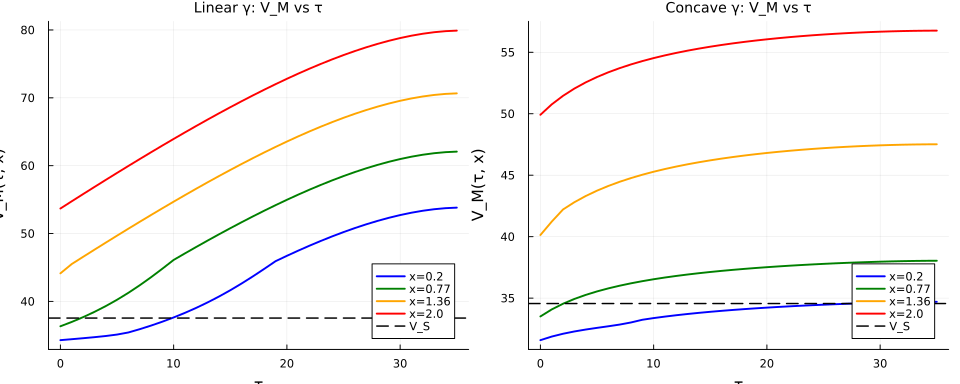

```julia
colors = [:blue, :green, :orange, :red]
Nx     = length(sol_lin.xg)
x_idxs = [1, div(Nx, 3), 2 * div(Nx, 3), Nx]

plt_lin = plot(title="Linear γ: V_M vs τ", xlabel="τ", ylabel="V_M(τ, x)",
               legend=:bottomright, titlefontsize=10)
for (i, col) in zip(x_idxs, colors)
    plot!(plt_lin, 0:p.T, sol_lin.VM[:, i], color=col,
          label="x=$(round(sol_lin.xg[i], digits=2))", lw=2)
end
hline!(plt_lin, [sol_lin.VS], color=:black, ls=:dash, label="V_S", lw=1.5)

plt_conc = plot(title="Concave γ: V_M vs τ", xlabel="τ", ylabel="V_M(τ, x)",
                legend=:bottomright, titlefontsize=10)
for (i, col) in zip(x_idxs, colors)
    plot!(plt_conc, 0:p_conc.T, sol_conc.VM[:, i], color=col,
          label="x=$(round(sol_conc.xg[i], digits=2))", lw=2)
end
hline!(plt_conc, [sol_conc.VS], color=:black, ls=:dash, label="V_S", lw=1.5)

plot(plt_lin, plt_conc, layout=(1, 2), size=(1000, 400))
```

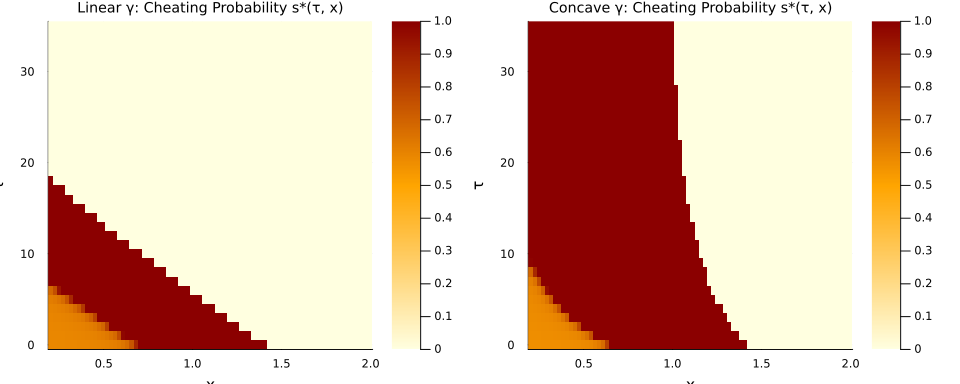

```julia
hm_lin = heatmap(sol_lin.xg, 0:p.T, sol_lin.s_star_grid,
                 title="Linear γ: Cheating Probability s*(τ, x)",
                 xlabel="x", ylabel="τ",
                 color=:heat, clims=(0, 1), titlefontsize=10)

hm_conc = heatmap(sol_conc.xg, 0:p_conc.T, sol_conc.s_star_grid,
                  title="Concave γ: Cheating Probability s*(τ, x)",
                  xlabel="x", ylabel="τ",
                  color=:heat, clims=(0, 1), titlefontsize=10)

plot(hm_lin, hm_conc, layout=(1, 2), size=(1000, 400))
```

## Steady State Distributions

Given the solution for cheating decisions in each state $s^*(\tau, x)$, the reservation quality $x^*$ for singles, and the reservation quality $x_C$ for cheaters, we can compute the steady-state distribution of marriages by forward recursion on marriage time $\tau$.

Let $n(\tau, x)$ be the measure of marriages (in pairs) with quality $x$ at time $\tau$. New matches form at $\tau = 0$ from two sources of singles meeting at rate $\alpha$ and cheaters leaving their current marriage. So the inflow of relationships is given by:

$$n(0, x) = \left[ \alpha \mathbb{1}\{x\geq x^* \}n(\tau, x) n_s + \alpha' \sum_{\tau, x} s^*(\tau, x) \mathbb{1}\{x\geq x_c\}n(\tau, x)\right]f(x)dx$$

Let $D_e(s^*())$ denote the endogenous dissolution probability of a marriage, which depends on the equilibrium cheating strategies. Combidng this with the exogenous separation rate of $\lambda$, the probability of a marriage dissolution $D$ is given by

$$D(\tau, x)= 1 - (1-\lambda)(1- D_e(s^*))$$

where $D_e(s^*)$ is given by the following cases:

- If $s^*(\tau, x) = 0$ (faithful equilibrium), then $D_e = 0$.
- If $s^*(\tau, x) = 1$ (cheating equilibrium), then marriage dissolves when at least one cheater finds a person worth leaving for: $D_e = 1.0 - (1.0 - p_c)^2$.
- If $s^*(\tau, x) \in (0, 1)$, $D_e = 1 -\mathbb{E}[survival | s^*]$, where the expectation averages survival probability across three outcome profiles, (F,F), (C,F), and (C,C), weighted by their likelihoods under $s^*$

From this, $n(\tau, x)$ evolves following:

$$n(\tau + 1, x) = (1 - D(\tau, x)) n(\tau, x)$$

`divorce_prob()` function from `steady_state.jl` calculates the probability of a marriage dissolution at each state $(\tau, x)$

Using this, we can simulate a cohort through $\tau$ and obtain the steady state distribution of married and single agents, as well as the divorce and infidelity rates. The `steady_state_distribution()` function does this. $x$ is fixed in a relationship, so we begin with an initial cohort and apply time -specific dissolution rates to determine the mass that survives to each subsequent period.

At each state $(\tau, x)$, the measure $n(\tau, x)$ is constant over time only if the inflow of survivors from $(\tau - 1, x)$ equals the outflow of matches that either dissolve or advance to $\tau + 1$. Imposing flow balance at every state simultaneously, the algorithm produces the steady state the distribution.

```julia
τ = 10
x_i = 2

prob_example = divorce_prob(τ, x_i, sol_lin, p)
println("the probability of a marriage dissolution in period 10 with a match value of 2 using linear γ is",  prob_example)

ss = steady_state_distribution(sol_lin, p)
println("Infidelity rate (linear γ):", round(ss.infidelity_rate, digits=2))
println("Divorce rate:", round(ss.divorce_rate, digits=2))
println("Avg marriage duration:", round(ss.avg_duration, digits=2))

ss_conc = steady_state_distribution(sol_conc, p_conc)
println("Infidelity rate (concave γ):", round(ss_conc.infidelity_rate, digits=2))
println("Divorce rate:", round(ss_conc.divorce_rate, digits=2))
println("Avg marriage duration:", round(ss_conc.avg_duration, digits=2))
```

```
the probability of a marriage dissolution in period 10 with a match value of 2 using linear γ is0.15826955175631174
Infidelity rate (linear γ):0.06
Divorce rate:0.03
Avg marriage duration:12.0
Infidelity rate (concave γ):0.09
Divorce rate:0.03
Avg marriage duration:11.43
```

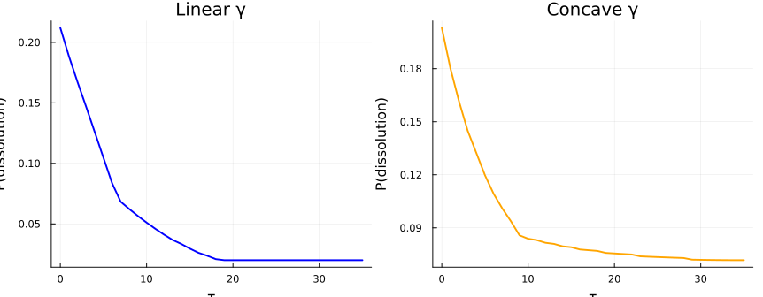

```julia
avg_D_lin  = [mean([divorce_prob(τ, i, sol_lin,  p)      for i in 1:length(xg)]) for τ in 0:p.T]
avg_D_conc = [mean([divorce_prob(τ, i, sol_conc, p_conc) for i in 1:length(xg)]) for τ in 0:p_conc.T]

plt_diss_lin = plot(0:p.T, avg_D_lin,
     xlabel="τ", ylabel="P(dissolution)",
     title="Linear γ",
     color=:blue, lw=2, legend=false)

plt_diss_conc = plot(0:p_conc.T, avg_D_conc,
     xlabel="τ", ylabel="P(dissolution)",
     title="Concave γ",
     color=:orange, lw=2, legend=false)

plot(plt_diss_lin, plt_diss_conc, layout=(1,2), size=(900, 350))
```

## Comparitive Statics

```julia
include("src/comparative_statics.jl")
```

```
Main.Notebook.plot_gamma_heatmaps_concave_γmax
```

### Divorce Cost Asymmetry

```
Converged in 41 iterations.
δ_C=1.00  δ_F=1.00  I=0.071  D=0.027
Converged in 39 iterations.
δ_C=1.25  δ_F=0.75  I=0.065  D=0.026
Converged in 40 iterations.
δ_C=1.50  δ_F=0.50  I=0.061  D=0.026
Converged in 39 iterations.
δ_C=1.74  δ_F=0.26  I=0.057  D=0.026
Converged in 40 iterations.
δ_C=1.99  δ_F=0.01  I=0.050  D=0.025
```

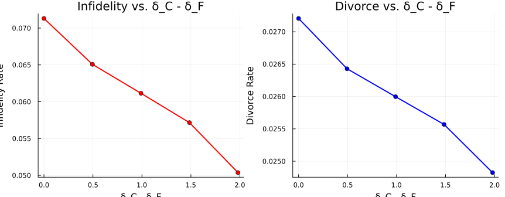

```julia
results_δ_lin = comparative_statics_δ(p; n_points=5)
plot_comparative_statics_δ(results_δ_lin)
```

```
Converged in 40 iterations.
δ_C=1.00  δ_F=1.00  I=0.120  D=0.032
Converged in 43 iterations.
δ_C=1.25  δ_F=0.75  I=0.107  D=0.031
Converged in 42 iterations.
δ_C=1.50  δ_F=0.50  I=0.090  D=0.029
Converged in 38 iterations.
δ_C=1.74  δ_F=0.26  I=0.080  D=0.028
Converged in 42 iterations.
δ_C=1.99  δ_F=0.01  I=0.074  D=0.027
```

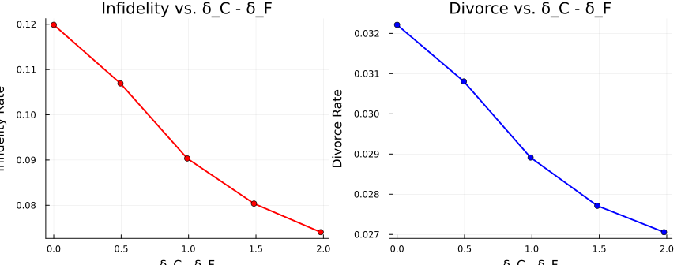

```julia
results_δ_conc = comparative_statics_δ(p_conc; n_points=5)
plot_comparative_statics_δ(results_δ_conc)
```

A higher divorce cost for the cheater relative to the faithful partner deters infidelity, and thus reduces the steady-statedivorce rates.

### Effect of $\rho$ on Outcomes

Changing the linear slope $\gamma$ and the concave curvature $\rho$ (at the default $\gamma_{\max}$) shows how the pace of marriage flow utility accumulation affects infidelity, divorce, and marriage duration.

```
Converged in 42 iterations.
Linear γ=0.010  I=0.120  D=0.031  dur=11.5
Converged in 41 iterations.
Linear γ=0.037  I=0.074  D=0.027  dur=11.8
Converged in 41 iterations.
Linear γ=0.064  I=0.062  D=0.026  dur=12.0
Converged in 41 iterations.
Linear γ=0.091  I=0.059  D=0.026  dur=12.0
Converged in 39 iterations.
Linear γ=0.119  I=0.056  D=0.026  dur=12.0
Converged in 40 iterations.
Linear γ=0.146  I=0.052  D=0.026  dur=12.1
Converged in 41 iterations.
Linear γ=0.173  I=0.051  D=0.026  dur=12.0
Converged in 41 iterations.
Linear γ=0.200  I=0.048  D=0.026  dur=12.1
Converged in 40 iterations.
Concave ρ=0.050  I=0.084  D=0.028  dur=11.7
Converged in 39 iterations.
Concave ρ=0.114  I=0.089  D=0.029  dur=11.5
Converged in 41 iterations.
Concave ρ=0.179  I=0.095  D=0.030  dur=11.3
Converged in 43 iterations.
Concave ρ=0.243  I=0.106  D=0.031  dur=11.1
Converged in 43 iterations.
Concave ρ=0.307  I=0.116  D=0.032  dur=10.9
Converged in 44 iterations.
Concave ρ=0.371  I=0.123  D=0.033  dur=10.8
Converged in 39 iterations.
Concave ρ=0.436  I=0.130  D=0.034  dur=10.6
Converged in 44 iterations.
Concave ρ=0.500  I=0.134  D=0.034  dur=10.6
```

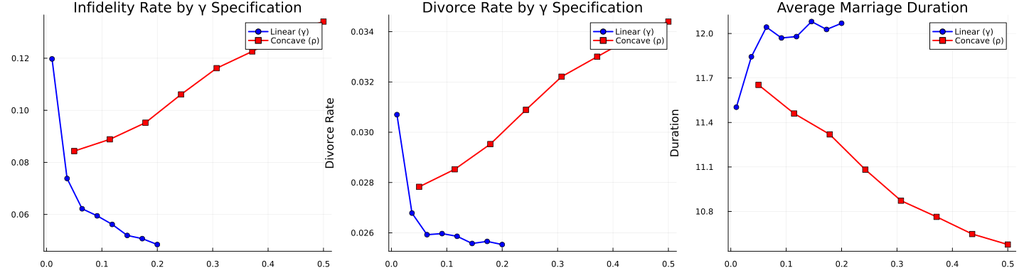

```julia
results_γ = comparative_statics_γ_all(p; n_points=8)
plot_comparative_statics_γ(results_γ)
```

A higher $\gamma$ in the linear case will make the flow utility of marriage grow faster. Since the growth is unbounded untill the terminal period $T$, an increase in $\gamma$ decreases infidelity and divorce rates, and increases the average marriage duration.

In the concave case, an increase in $\rho$ increases infidelity and divorce rates, and decreases the average marriage duration. This is because the default parameter $\gamma_{\max}$ is small, so once the marriage flow utility growth stalls, the continuation value of marriage does not rise much with marriage duration. A higher curvature $\rho$ in the concave case will make the flow utility of marriage grow faster at the beginning, but it will also stall sooner.

```
Converged in 40 iterations.
Concave ρ=0.050  I=0.039  D=0.025  dur=12.3
Converged in 39 iterations.
Concave ρ=0.114  I=0.024  D=0.023  dur=13.4
Converged in 39 iterations.
Concave ρ=0.179  I=0.019  D=0.022  dur=13.8
Converged in 37 iterations.
Concave ρ=0.243  I=0.017  D=0.022  dur=14.0
Converged in 38 iterations.
Concave ρ=0.307  I=0.015  D=0.022  dur=14.1
Converged in 39 iterations.
Concave ρ=0.371  I=0.014  D=0.021  dur=14.3
Converged in 39 iterations.
Concave ρ=0.436  I=0.013  D=0.021  dur=14.3
Converged in 41 iterations.
Concave ρ=0.500  I=0.013  D=0.021  dur=14.4
```

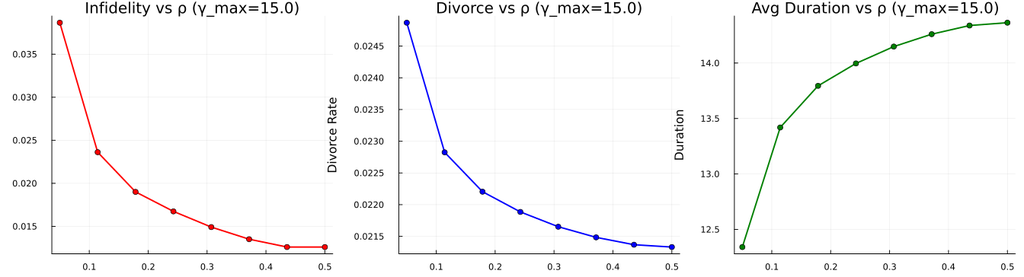

```julia
γ_max_hi = 15.0
res_conc_hi = comparative_statics_γ_concave(p; n_points=8, γ_max=γ_max_hi)

ρ_vals_hi = [r.ρ for r in res_conc_hi]

p_inf = plot(ρ_vals_hi, [r.infidelity_rate for r in res_conc_hi],
             color=:red, lw=2, marker=:circle, legend=false,
             title="Infidelity vs ρ (γ_max=$γ_max_hi)", xlabel="ρ", ylabel="Infidelity Rate")
p_div = plot(ρ_vals_hi, [r.divorce_rate for r in res_conc_hi],
             color=:blue, lw=2, marker=:circle, legend=false,
             title="Divorce vs ρ (γ_max=$γ_max_hi)", xlabel="ρ", ylabel="Divorce Rate")
p_dur = plot(ρ_vals_hi, [r.avg_duration for r in res_conc_hi],
             color=:green, lw=2, marker=:circle, legend=false,
             title="Avg Duration vs ρ (γ_max=$γ_max_hi)", xlabel="ρ", ylabel="Duration")
plot(p_inf, p_div, p_dur, layout=(1, 3), size=(1400, 380))
```

If we give the concave case very higher long-run asymptote $\gamma_{\max}$, then reaching $\gamma_{\max}$ sooner makes remaining in the marriage more attractive. Therefore, in this case, a higher curvature $\rho$ actually reduces infidelity and divorce rates, and increases the average marriage duration.

#### Cheating Heatmaps: Linear $\gamma$

```
Converged in 40 iterations.
Converged in 41 iterations.
Converged in 41 iterations.
Converged in 41 iterations.
```

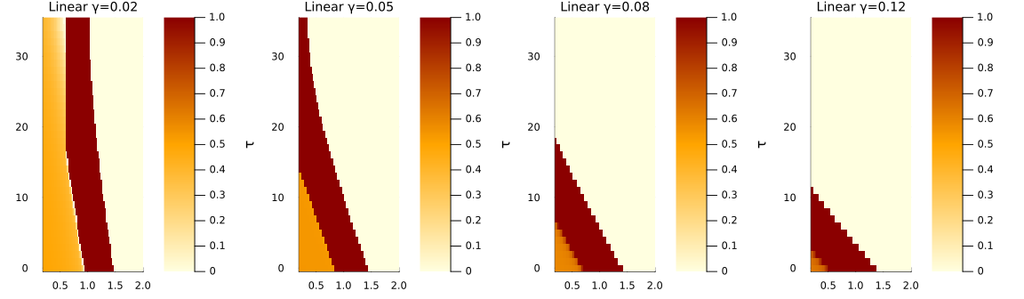

```julia
sols_lin, params_lin, γ_vals = gamma_heatmap_solutions_linear(p)
plot_gamma_heatmaps_linear(sols_lin, params_lin, γ_vals)
```

A faster growth rate of marriage flow utility in the linear case reduces the region of cheating equilibria.

#### Cheating Heatmaps: Concave $\gamma$, Varying $\rho$

```
Converged in 40 iterations.
Converged in 41 iterations.
Converged in 41 iterations.
Converged in 40 iterations.
```

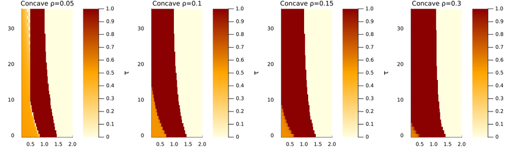

```julia
sols_conc, params_conc, ρ_vals = gamma_heatmap_solutions_concave(p_conc)
plot_gamma_heatmaps_concave(sols_conc, params_conc, ρ_vals)
```

In the concave case with the default $\gamma_{\max}$, a higher curvature $\rho$ increases the region of cheating equilibria when $\gamma_{\max}$ is small.

#### Changing $\gamma_{\max}$ in the Concave Case

```
Converged in 42 iterations.
Converged in 38 iterations.
Converged in 41 iterations.
Converged in 39 iterations.
```

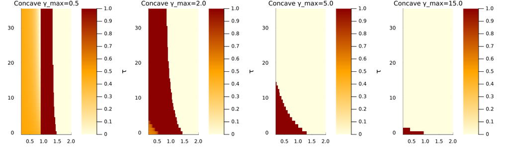

```julia
sols_conc_gmax, params_conc_gmax, γmax_vals = gamma_heatmap_solutions_concave_γmax(p_conc)
plot_gamma_heatmaps_concave_γmax(sols_conc_gmax, params_conc_gmax, γmax_vals)
```

When $\gamma_{\max}$ is very high, a higher curvature $\rho$ reduces the region of cheating equilibria, as it makes the flow utility of marriage grow faster at the beginning, and the long-run asymptote is high enough to make remaining in the marriage more attractive.

## References

Burdett, Kenneth, Ryoichi Imai, and Randall Wright. 2002. “Unstable Relationships,” May. https://doi.org/10.2202/1534-6021.1102.

Jovanovic, Boyan. 1979. “Job Matching and the Theory of Turnover.” *Journal of Political Economy* 87 (5, Part 1): 972–90. https://doi.org/10.1086/260808.